# Trawl vs. eDNA Metabarcoding: Community Survey Comparison

Published

May 1, 2026

# Overview

This report harmonizes paired trawl survey and eDNA metabarcoding datasets collected at the same stations, then tests:

1. **Rank correlation** (Spearman’s ρ) between trawl catch and eDNA read abundance
2. **Relative abundance correlation** across all paired station × species observations
3. **Differences among eDNA sample types** (e.g. filter type, replicate type) in their correlation with trawl data

# 1. Setup & Data Loading

```r
library(tidyverse)
library(data.table)
library(vegan)
library(ggplot2)
library(ggrepel)
library(patchwork)
library(knitr)
library(kableExtra)
library(broom)
library(ggvenn)

# ── USER: Update these file paths ────────────────────────────────────────────
trawl_file      <- "inputs/trawl_taxa_subset.csv"          # Long-format trawl CSV
edna_spp_file   <- "inputs/SPECIES_counts_Trawl_CEPH18s.csv"  # Species-collapsed table: rows = species,
                                              #   cols = sample IDs + "Species" + "full_tax"
edna_meta_file  <- "inputs/eDNA_Metabarcoding_Metadata_EG301-584_metadata.csv"       # Sample metadata: sample_id + sample_type + station_id
lookup_file     <- "inputs/species_types.csv"        # Common-name ↔ binomial lookup table

# ── USER: Update these column names to match your files ──────────────────────
# Trawl columns
trawl_station_col  <- "TowID"   # Station/site identifier
trawl_species_col  <- "Common_Name"      # Common name column in trawl (e.g. "Atlantic Cod")
trawl_count_col    <- "Expanded_Catch"        # Individual counts  — set to NA if column absent
trawl_weight_col   <- "Expanded_Weight_kg"    # Biomass column     — set to NA if column absent
                                     # Both columns are retained; correlations run for each

# eDNA species table columns
edna_species_col   <- "Species"      # Binomial species name column in the eDNA table
edna_tax_col       <- "full_tax"     # Full taxonomy string column (kept but not required)

# Lookup table columns (species_types.csv)
lookup_common_col  <- "Common_Name"  # Common name column  → matches trawl species
lookup_binom_col   <- "Species"      # Binomial name column → matches eDNA species
lookup_group_col   <- "Fish_Invert"  # Taxonomic group (Fish / Invertebrate)
lookup_type_col    <- "Body_Type"    # Body type (Slimy / Crunchy) — optional stratifier

# eDNA metadata columns
meta_sample_col    <- "ReadFile"    # Sample identifier (must match column names in edna_spp_file)
meta_station_col   <- "TrawlID"   # Station identifier (must match trawl station IDs)
meta_type_col      <- "Sample_type"  # Column distinguishing the 3 sample types
# ─────────────────────────────────────────────────────────────────────────────
```

```r
# Load files
trawl_raw    <- read_csv(trawl_file,     show_col_types = FALSE)
edna_spp_raw <- read_csv(edna_spp_file,  show_col_types = FALSE)
meta_raw     <- read_csv(edna_meta_file, show_col_types = FALSE)
lookup_raw   <- read_csv(lookup_file,    show_col_types = FALSE)

cat("Trawl rows:", nrow(trawl_raw), "\n")
```

```
Trawl rows: 220
```

```r
cat("eDNA species table:", nrow(edna_spp_raw), "species ×", ncol(edna_spp_raw), "columns\n")
```

```
eDNA species table: 4 species × 27 columns
```

```r
cat("eDNA metadata rows:", nrow(meta_raw), "\n")
```

```
eDNA metadata rows: 182
```

```r
cat("Lookup table rows:", nrow(lookup_raw), "\n")
```

```
Lookup table rows: 52
```

# 2. Data Harmonization

## 2a. Trawl Data — Clean & Summarize

```r
trawl <- trawl_raw %>%
  rename(
    station     = all_of(trawl_station_col),
    common_name = all_of(trawl_species_col)
  ) %>%
  mutate(common_name = str_squish(common_name))

# Retain both count and biomass columns where available
has_count  <- !is.na(trawl_count_col)  && trawl_count_col  %in% names(trawl)
has_weight <- !is.na(trawl_weight_col) && trawl_weight_col %in% names(trawl)

if (!has_count && !has_weight)
  stop("Neither count nor weight column found in trawl data.")

if (has_count)  trawl <- trawl %>% rename(trawl_count  = all_of(trawl_count_col))
if (has_weight) trawl <- trawl %>% rename(trawl_weight = all_of(trawl_weight_col))

# Aggregate in case of duplicates within station × species
trawl_agg <- trawl %>%
  group_by(station, common_name) %>%
  summarise(
    across(any_of(c("trawl_count", "trawl_weight")),
           ~ sum(.x, na.rm = TRUE)),
    .groups = "drop"
  )

cat("Trawl stations:", n_distinct(trawl_agg$station), "\n")
```

```
Trawl stations: 11
```

```r
cat("Trawl species (common names):", n_distinct(trawl_agg$common_name), "\n")
```

```
Trawl species (common names): 52
```

```r
cat("Count column present:", has_count, "| Weight column present:", has_weight, "\n")
```

```
Count column present: TRUE | Weight column present: TRUE
```

## 2b. eDNA Data — Pivot Species Table to Long Format

Your eDNA table has species as rows and sample IDs as columns, with `Species` and `full_tax` as annotation columns. This chunk pivots it to long format and filters unassigned rows.

```r
# Identify annotation columns vs sample ID columns
annot_cols <- c(edna_species_col, edna_tax_col)
sample_cols <- setdiff(names(edna_spp_raw), annot_cols)

edna_long <- edna_spp_raw %>%
  # Drop rows with no species assignment
  filter(!is.na(.data[[edna_species_col]]),
         .data[[edna_species_col]] != "na",
         .data[[edna_species_col]] != "") %>%
  # Standardize species name formatting
  mutate(species = str_to_sentence(str_squish(.data[[edna_species_col]]))) %>%
  select(species, full_tax = all_of(edna_tax_col), all_of(sample_cols)) %>%
  pivot_longer(
    cols      = all_of(sample_cols),
    names_to  = "sample_id",
    values_to = "reads"
  ) %>%
  filter(reads > 0)

cat("eDNA samples:", n_distinct(edna_long$sample_id), "\n")
```

```
eDNA samples: 23
```

```r
cat("eDNA species (assigned):", n_distinct(edna_long$species), "\n")
```

```
eDNA species (assigned): 3
```

```r
cat("Non-zero read observations:", nrow(edna_long), "\n")
```

```
Non-zero read observations: 32
```

## 2c. Species Name Harmonization via Lookup Table

The trawl uses common names; the eDNA table uses binomial names. The lookup table (`species_types.csv`) bridges them. This chunk adds the binomial key to trawl records and flags any common names not found in the lookup.

```r
# Clean lookup table
lookup <- lookup_raw %>%
  rename(
    common_name  = all_of(lookup_common_col),
    species      = all_of(lookup_binom_col),
    taxon_group  = all_of(lookup_group_col),
    body_type    = all_of(lookup_type_col)
  ) %>%
  mutate(
    common_name = str_squish(common_name),
    species     = str_to_sentence(str_squish(species))
  ) %>%
  select(common_name, species, taxon_group, body_type)

# Join binomial name onto trawl aggregated data
trawl_agg <- trawl_agg %>%
  left_join(lookup, by = "common_name")

# Report any trawl common names missing from the lookup
unmatched_trawl <- trawl_agg %>%
  filter(is.na(species)) %>%
  distinct(common_name)

if (nrow(unmatched_trawl) > 0) {
  message("⚠ These trawl common names were NOT found in the lookup table and will be excluded from correlations:")
  print(unmatched_trawl)
} else {
  cat("✓ All trawl common names matched in lookup table.\n")
}
```

```
✓ All trawl common names matched in lookup table.
```

```r
# Report eDNA binomials not in lookup (detected but no trawl equivalent expected)
unmatched_edna <- edna_spp_raw %>%
  pull(.data[[edna_species_col]]) %>%
  # Exclude unassigned rows before any transformation
  keep(~ !is.na(.x) && !tolower(str_squish(.x)) %in% c("na", "")) %>%
  str_to_sentence() %>% str_squish() %>% unique() %>%
  setdiff(lookup$species)
cat("\neDNA species not in lookup table (", length(unmatched_edna), "):",
    paste(head(unmatched_edna, 10), collapse = ", "),
    if (length(unmatched_edna) > 10) "..." else "", "\n")
```

```
eDNA species not in lookup table ( 0 ):
```

```r
# Keep only trawl records with a matched binomial
trawl_agg <- trawl_agg %>% filter(!is.na(species))
```

## 2d. eDNA — Attach Metadata & Summarize by Station × Type

```r
meta_clean <- meta_raw %>%
  rename(
    sample_id   = all_of(meta_sample_col),
    station     = all_of(meta_station_col),
    sample_type = all_of(meta_type_col)
  )

edna_full <- edna_long %>%
  left_join(meta_clean, by = "sample_id")

# Warn about any samples in eDNA table not found in metadata
missing_meta <- setdiff(unique(edna_long$sample_id), meta_clean$sample_id)
if (length(missing_meta) > 0)
  warning("These sample IDs are in the eDNA table but not in metadata: ",
          paste(missing_meta, collapse = ", "))

# Summarize reads per station × sample_type × species
edna_agg <- edna_full %>%
  filter(!is.na(station), !is.na(sample_type)) %>%
  group_by(station, sample_type, species) %>%
  summarise(edna_reads = sum(reads, na.rm = TRUE), .groups = "drop")

cat("eDNA sample types:", paste(sort(unique(edna_agg$sample_type)), collapse = ", "), "\n")
```

```
eDNA sample types: Bottom_metaprobe, Slush, Top_metaprobe
```

```r
cat("eDNA stations:", n_distinct(edna_agg$station), "\n")
```

```
eDNA stations: 7
```

## 2e. Join Trawl & eDNA

```r
# Paired stations present in both datasets
shared_stations <- intersect(unique(trawl_agg$station), unique(edna_agg$station))
cat("Paired stations (trawl ∩ eDNA):", length(shared_stations), "\n")
```

```
Paired stations (trawl ∩ eDNA): 7
```

```r
# Full join on binomial species name within paired stations
paired <- trawl_agg %>%
  filter(station %in% shared_stations) %>%
  full_join(
    edna_agg %>% filter(station %in% shared_stations),
    by = c("station", "species")
  ) %>%
  # Fill zeros for species absent from one method at a given station
  mutate(
    across(any_of(c("trawl_count", "trawl_weight")), ~ replace_na(.x, 0)),
    edna_reads = replace_na(edna_reads, 0)
  ) %>%
  # Carry lookup metadata forward (taxon_group, body_type)
  left_join(lookup %>% select(species, taxon_group, body_type), by = "species")

# Relative abundances within each station × sample_type (computed per metric)
paired <- paired %>%
  group_by(station, sample_type) %>%
  mutate(
    edna_rel = edna_reads / sum(edna_reads, na.rm = TRUE)
  ) %>%
  ungroup()

if (has_count) {
  paired <- paired %>%
    group_by(station, sample_type) %>%
    mutate(trawl_count_rel = trawl_count / sum(trawl_count, na.rm = TRUE)) %>%
    ungroup()
}
if (has_weight) {
  paired <- paired %>%
    group_by(station, sample_type) %>%
    mutate(trawl_weight_rel = trawl_weight / sum(trawl_weight, na.rm = TRUE)) %>%
    ungroup()
}

both_detected <- paired %>% filter(edna_reads > 0)
if (has_count)  both_detected <- both_detected %>% filter(trawl_count  > 0)
if (has_weight) both_detected <- both_detected %>% filter(trawl_weight > 0)

cat("Species × station pairs detected by both methods:", nrow(both_detected), "\n")
```

```
Species × station pairs detected by both methods: 11
```

# 3. Exploratory Summaries

## Species overlap per station

All trawl stations are shown regardless of whether a paired eDNA sample exists. Stations with no eDNA data show `—` in the eDNA columns.

```r
trawl_pa_col <- if (has_count) "trawl_count" else "trawl_weight"

# All trawl stations (the authoritative list)
all_trawl_stations <- trawl_agg %>% distinct(station) %>% arrange(station)

# eDNA summary per station × sample_type
edna_summary <- paired %>%
  filter(!is.na(sample_type)) %>%
  group_by(station, sample_type) %>%
  summarise(
    n_edna = sum(edna_reads > 0),
    n_both = sum(.data[[trawl_pa_col]] > 0 & edna_reads > 0, na.rm = TRUE),
    .groups = "drop"
  )

# Trawl summary per station (independent of eDNA sample_type)
trawl_summary <- trawl_agg %>%
  filter(station %in% all_trawl_stations$station) %>%
  group_by(station) %>%
  summarise(n_trawl = sum(.data[[trawl_pa_col]] > 0, na.rm = TRUE), .groups = "drop")

# Full cross of all trawl stations × eDNA sample types that exist in the data
edna_types <- sort(unique(na.omit(paired$sample_type)))
full_grid <- expand.grid(
  station     = all_trawl_stations$station,
  sample_type = edna_types,
  stringsAsFactors = FALSE
)

overlap_tbl <- full_grid %>%
  left_join(trawl_summary, by = "station") %>%
  left_join(edna_summary,  by = c("station", "sample_type")) %>%
  mutate(
    has_edna   = station %in% unique(edna_agg$station),
    n_edna_chr = if_else(!has_edna, "—", as.character(replace_na(n_edna, 0))),
    n_both_chr = if_else(!has_edna, "—", as.character(replace_na(n_both, 0))),
    pct_shared = if_else(
      !has_edna | is.na(n_both), "—",
      paste0(round(100 * n_both / pmax(n_trawl, 1), 1), "%")
    )
  ) %>%
  select(station, sample_type, n_trawl, n_edna_chr, n_both_chr, pct_shared) %>%
  arrange(station, sample_type)

overlap_tbl %>%
  kable(
    caption   = "Species detected per station by each method (all trawl stations shown)",
    col.names = c("Station", "eDNA sample type", "Trawl spp.", "eDNA spp.", "Shared spp.", "% Shared"),
    align     = c("l","l","c","c","c","c")
  ) %>%
  kable_styling(bootstrap_options = c("striped", "hover", "condensed"), full_width = FALSE) %>%
  collapse_rows(columns = 1, valign = "top")
```

Species detected per station by each method (all trawl stations shown)

| Station | eDNA sample type | Trawl spp. | eDNA spp. | Shared spp. | % Shared |
| --- | --- | --- | --- | --- | --- |
| FL23018 | Bottom_metaprobe | 16 | 2 | 1 | 6.2% |
|  | Slush | 16 | 1 | 1 | 6.2% |
|  | Top_metaprobe | 16 | 2 | 1 | 6.2% |
| FL23019 | Bottom_metaprobe | 20 | 1 | 1 | 5% |
|  | Slush | 20 | 1 | 1 | 5% |
|  | Top_metaprobe | 20 | 2 | 1 | 5% |
| FL23020 | Bottom_metaprobe | 18 | 1 | 1 | 5.6% |
|  | Slush | 18 | 0 | 0 | — |
|  | Top_metaprobe | 18 | 1 | 1 | 5.6% |
| FL23072 | Bottom_metaprobe | 19 | 2 | 0 | 0% |
|  | Slush | 19 | 0 | 0 | — |
|  | Top_metaprobe | 19 | 0 | 0 | — |
| FL23075 | Bottom_metaprobe | 20 | 0 | 0 | — |
|  | Slush | 20 | 0 | 0 | — |
|  | Top_metaprobe | 20 | 1 | 0 | 0% |
| SP23018 | Bottom_metaprobe | 21 | — | — | — |
|  | Slush | 21 | — | — | — |
|  | Top_metaprobe | 21 | — | — | — |
| SP23019 | Bottom_metaprobe | 21 | — | — | — |
|  | Slush | 21 | — | — | — |
|  | Top_metaprobe | 21 | — | — | — |
| SP23020 | Bottom_metaprobe | 23 | — | — | — |
|  | Slush | 23 | — | — | — |
|  | Top_metaprobe | 23 | — | — | — |
| SP23088 | Bottom_metaprobe | 19 | — | — | — |
|  | Slush | 19 | — | — | — |
|  | Top_metaprobe | 19 | — | — | — |
| SP23094 | Bottom_metaprobe | 23 | 2 | 1 | 4.3% |
|  | Slush | 23 | 0 | 0 | — |
|  | Top_metaprobe | 23 | 2 | 1 | 4.3% |
| SP23096 | Bottom_metaprobe | 20 | 2 | 1 | 5% |
|  | Slush | 20 | 0 | 0 | — |
|  | Top_metaprobe | 20 | 1 | 0 | 0% |

## Species overlap Venn diagrams

Four pairwise comparisons between trawl and each eDNA sample type (plus all eDNA types pooled). Species sets are based on detections across **all paired stations**. Shared species are listed below each diagram.

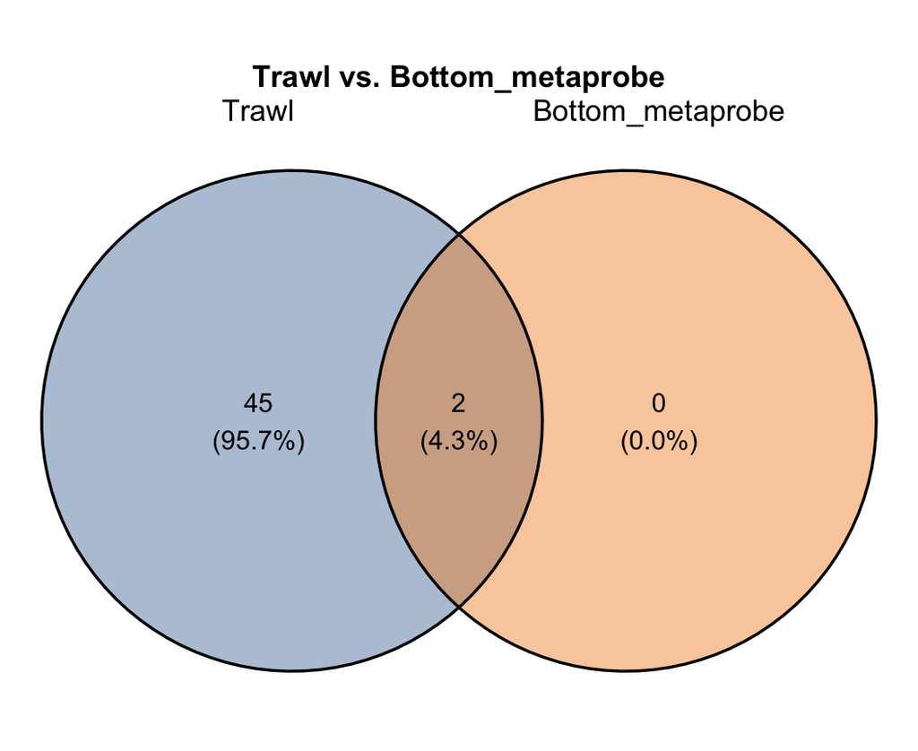

```
**Shared species (n = 2 ):**
- *Doryteuthis pealeii*
- *Illex illecebrosus*

**Trawl only (n = 45 ):**  Alosa aestivalis, Alosa pseudoharengus, Alosa sapidissima, Ambyyraja radiata, Artica islandica, Atractosteus spatula, Bathypolypus arcticus, Cancer borealis, Cancer irroratus, Clupea harengus, Crangon vulgaris, Cryptacanthodes maculatus, Ctenophora, Cyclocardia borealis, C…

** Bottom_metaprobe only (n = 0 ):**  None

---
```

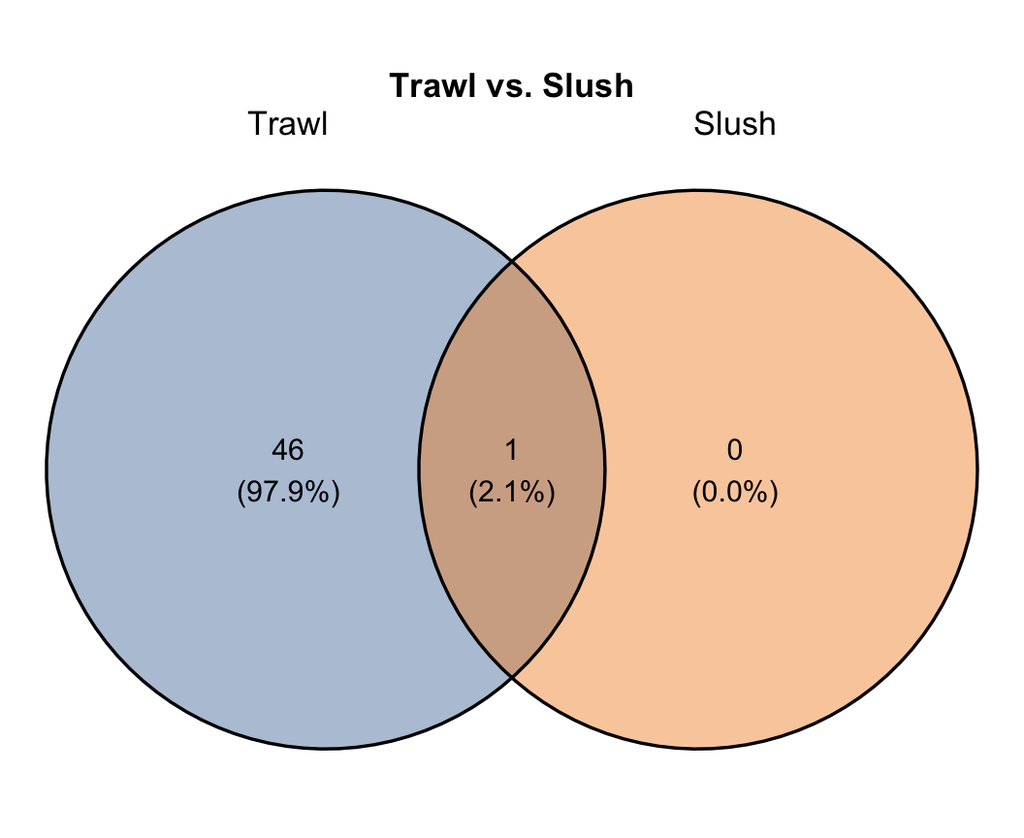

```
**Shared species (n = 1 ):**
- *Illex illecebrosus*

**Trawl only (n = 46 ):**  Alosa aestivalis, Alosa pseudoharengus, Alosa sapidissima, Ambyyraja radiata, Artica islandica, Atractosteus spatula, Bathypolypus arcticus, Cancer borealis, Cancer irroratus, Clupea harengus, Crangon vulgaris, Cryptacanthodes maculatus, Ctenophora, Cyclocardia borealis, C…

** Slush only (n = 0 ):**  None

---
```

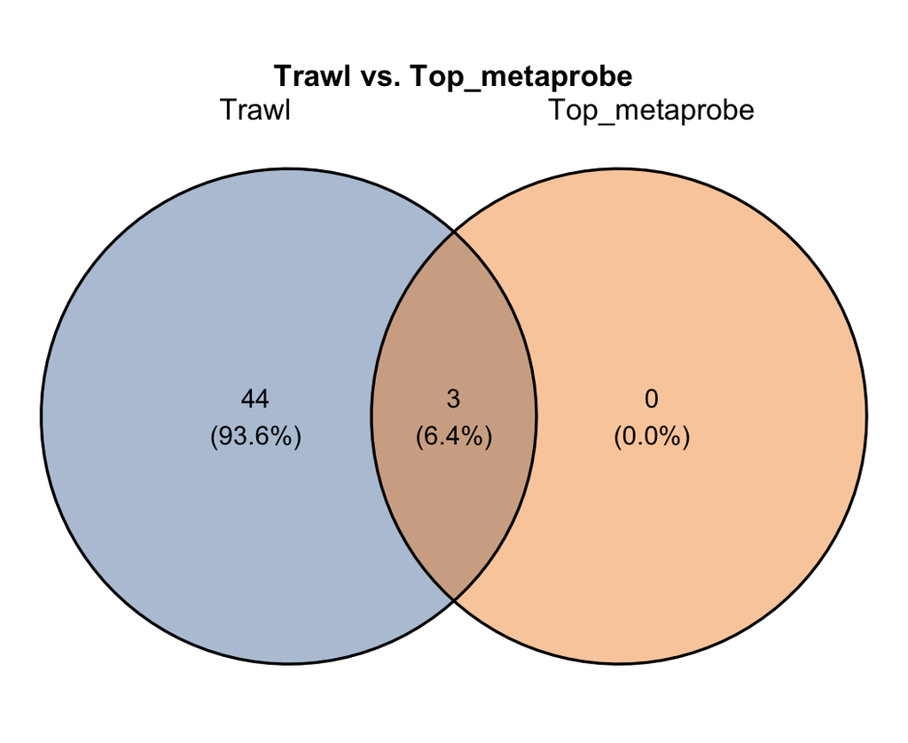

```
**Shared species (n = 3 ):**
- *Bathypolypus arcticus*
- *Doryteuthis pealeii*
- *Illex illecebrosus*

**Trawl only (n = 44 ):**  Alosa aestivalis, Alosa pseudoharengus, Alosa sapidissima, Ambyyraja radiata, Artica islandica, Atractosteus spatula, Cancer borealis, Cancer irroratus, Clupea harengus, Crangon vulgaris, Cryptacanthodes maculatus, Ctenophora, Cyclocardia borealis, Cyclopterus lumpus, Dipt…

** Top_metaprobe only (n = 0 ):**  None

---
```

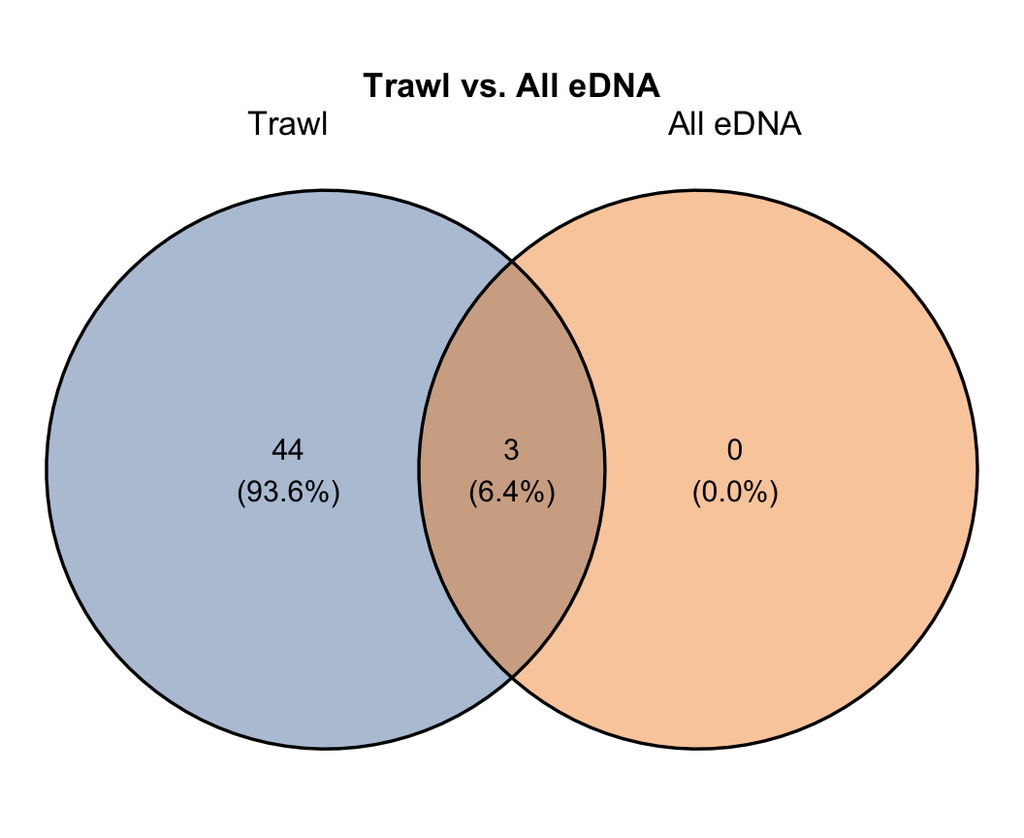

```
**Shared species (n = 3 ):**
- *Bathypolypus arcticus*
- *Doryteuthis pealeii*
- *Illex illecebrosus*

**Trawl only (n = 44 ):**  Alosa aestivalis, Alosa pseudoharengus, Alosa sapidissima, Ambyyraja radiata, Artica islandica, Atractosteus spatula, Cancer borealis, Cancer irroratus, Clupea harengus, Crangon vulgaris, Cryptacanthodes maculatus, Ctenophora, Cyclocardia borealis, Cyclopterus lumpus, Dipt…

** All eDNA only (n = 0 ):**  None

---
```

```r
# Species sets — trawl and each eDNA type, restricted to shared stations
trawl_spp_set <- trawl_agg %>%
  filter(station %in% shared_stations, .data[[trawl_pa_col]] > 0) %>%
  pull(species) %>% unique() %>% sort()

edna_spp_by_type <- edna_agg %>%
  filter(station %in% shared_stations, edna_reads > 0) %>%
  group_by(sample_type) %>%
  summarise(species = list(sort(unique(species))), .groups = "drop") %>%
  deframe()   # named list: sample_type -> character vector of species

# Add pooled "All eDNA" set
edna_spp_by_type[["All eDNA"]] <- edna_agg %>%
  filter(station %in% shared_stations, edna_reads > 0) %>%
  pull(species) %>% unique() %>% sort()

# Helper: draw one Venn + print shared species beneath
venn_with_list <- function(edna_type, edna_spp) {
  shared <- sort(intersect(trawl_spp_set, edna_spp))
  only_trawl <- sort(setdiff(trawl_spp_set, edna_spp))
  only_edna  <- sort(setdiff(edna_spp, trawl_spp_set))

  venn_sets <- list(Trawl = trawl_spp_set, eDNA = edna_spp)
  names(venn_sets)[2] <- edna_type

  p <- ggvenn(
    venn_sets,
    fill_color   = c("#4e79a7", "#f28e2b"),
    fill_alpha   = 0.45,
    stroke_size  = 0.6,
    text_size    = 4,
    set_name_size = 4.5
  ) +
    labs(title = paste("Trawl vs.", edna_type)) +
    theme(plot.title = element_text(hjust = 0.5, face = "bold", size = 13))

  print(p)

  # Species lists beneath the diagram
  cat("\n**Shared species (n =", length(shared), "):**\n")
  if (length(shared) > 0) {
    cat(paste0("- *", shared, "*", collapse = "\n"), "\n")
  } else {
    cat("- None\n")
  }

  cat("\n**Trawl only (n =", length(only_trawl), "):**",
      if (length(only_trawl) > 0) paste0(" ", paste(only_trawl, collapse = ", ")) else " None",
      "\n")
  cat("\n**", edna_type, "only (n =", length(only_edna), "):**",
      if (length(only_edna) > 0) paste0(" ", paste(only_edna, collapse = ", ")) else " None",
      "\n\n---\n\n")
}

# Draw each comparison
for (etype in c(sort(names(edna_spp_by_type)[names(edna_spp_by_type) != "All eDNA"]),
                "All eDNA")) {
  venn_with_list(etype, edna_spp_by_type[[etype]])
}
```

## Per-species heatmaps: relative abundance × station × method

Each panel shows one species detected by **both** trawl and eDNA across paired stations. Rows = all trawl stations; columns = Trawl + eDNA sample types. Colour encodes **trawl relative abundance** (Trawl column) or **raw eDNA read counts** (eDNA columns), scaled 0–1 within each column. Grey tiles = stations with no eDNA sample.

```
Species detected by both methods: Bathypolypus arcticus, Doryteuthis pealeii, Illex illecebrosus
```

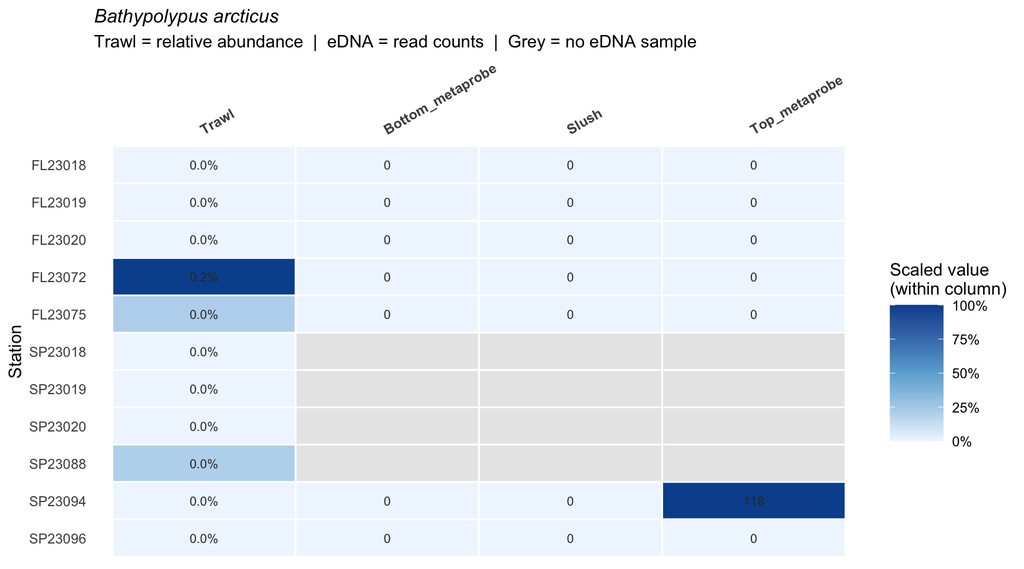

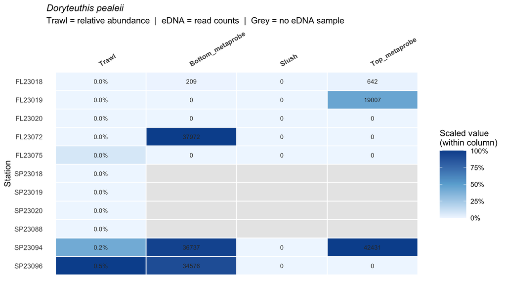

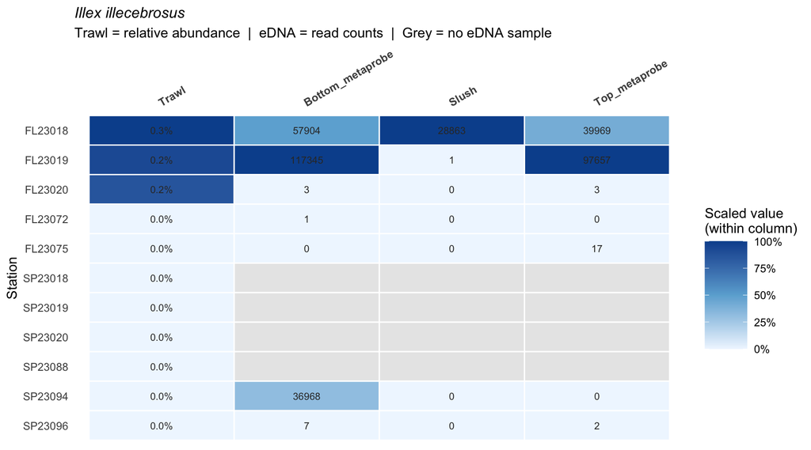

```r
# ── Build the heatmap data ────────────────────────────────────────────────────
trawl_heat <- trawl_agg %>%
  filter(station %in% all_trawl_stations$station) %>%
  group_by(station) %>%
  mutate(trawl_rel_abund = .data[[trawl_pa_col]] / sum(.data[[trawl_pa_col]], na.rm = TRUE)) %>%
  ungroup() %>%
  select(station, species, value = trawl_rel_abund) %>%
  mutate(col_group = "Trawl")

edna_heat <- edna_agg %>%
  filter(station %in% all_trawl_stations$station) %>%
  rename(value = edna_reads) %>%
  mutate(col_group = sample_type) %>%
  select(station, species, value, col_group)

col_levels <- c("Trawl", sort(unique(edna_heat$col_group)))

# ── Restrict to species detected by BOTH trawl and eDNA ──────────────────────
trawl_detected <- trawl_agg %>%
  filter(station %in% shared_stations, .data[[trawl_pa_col]] > 0) %>%
  pull(species) %>% unique()

edna_detected <- edna_agg %>%
  filter(station %in% shared_stations, edna_reads > 0) %>%
  pull(species) %>% unique()

both_species <- sort(intersect(trawl_detected, edna_detected))

if (length(both_species) == 0) {
  cat("No species detected by both trawl and eDNA in paired stations.\n")
} else {
  cat("Species detected by both methods:", paste(both_species, collapse = ", "), "\n")

  heat_grid <- expand.grid(
    station   = all_trawl_stations$station,
    species   = both_species,
    col_group = col_levels,
    stringsAsFactors = FALSE
  )

  heat_data <- heat_grid %>%
    left_join(bind_rows(trawl_heat, edna_heat),
              by = c("station", "species", "col_group")) %>%
    mutate(
      has_edna  = station %in% unique(edna_agg$station),
      is_trawl  = col_group == "Trawl",
      missing   = !is_trawl & !has_edna,
      value     = if_else(missing, NA_real_, replace_na(value, 0)),
      col_group = factor(col_group, levels = col_levels),
      station   = factor(station, levels = rev(all_trawl_stations$station))
    )

  for (sp in both_species) {
    sp_data <- heat_data %>% filter(species == sp)

    sp_data <- sp_data %>%
      group_by(col_group) %>%
      mutate(value_scaled = case_when(
        is.na(value)                  ~ NA_real_,
        max(value, na.rm = TRUE) == 0 ~ 0,
        TRUE ~ value / max(value, na.rm = TRUE)
      )) %>%
      ungroup()

    p <- ggplot(sp_data, aes(x = col_group, y = station, fill = value_scaled)) +
      geom_tile(color = "white", linewidth = 0.5) +
      geom_text(
        aes(label = case_when(
          missing      ~ "",
          is.na(value) ~ "0",
          is_trawl     ~ scales::percent(value, accuracy = 0.1),
          TRUE         ~ as.character(round(value))
        )),
        size = 2.8, color = "grey20"
      ) +
      scale_fill_gradientn(
        colours  = c("#f0f7ff", "#6baed6", "#08519c"),
        na.value = "#e8e8e8",
        limits   = c(0, 1),
        labels   = scales::percent,
        name     = "Scaled value\n(within column)"
      ) +
      scale_x_discrete(position = "top") +
      labs(
        title    = paste0("*", sp, "*"),
        subtitle = "Trawl = relative abundance  |  eDNA = read counts  |  Grey = no eDNA sample",
        x = NULL, y = "Station"
      ) +
      theme_minimal(base_size = 11) +
      theme(
        plot.title       = ggtext::element_markdown(face = "italic", size = 12),
        axis.text.x      = element_text(angle = 30, hjust = 0, face = "bold"),
        panel.grid       = element_blank(),
        legend.key.width = unit(1.2, "cm")
      )

    print(p)
  }
}
```

# 4. Rank Correlation (Spearman’s ρ)

## 4a. Overall rank correlation per sample type

Spearman’s ρ is calculated across all station × species pairs within each eDNA sample type, separately for **count** and **biomass** where both are available. This lets you directly compare which trawl metric correlates more strongly with eDNA read abundance.

```r
# Helper: compute Spearman ρ + p for one trawl metric
spearman_tbl <- function(df, trawl_col, metric_label) {
  df %>%
    filter(!is.na(sample_type), !is.na(.data[[trawl_col]])) %>%
    group_by(sample_type) %>%
    filter(
      sum(!is.na(.data[[trawl_col]]) & !is.na(edna_reads)) >= 3,
      var(.data[[trawl_col]], na.rm = TRUE) > 0,
      var(edna_reads,         na.rm = TRUE) > 0
    ) %>%
    summarise(
      trawl_metric = metric_label,
      n_obs   = n(),
      rho     = tryCatch(
        cor(.data[[trawl_col]], edna_reads, method = "spearman", use = "complete.obs"),
        error = function(e) NA_real_
      ),
      p_value = tryCatch(
        cor.test(.data[[trawl_col]], edna_reads, method = "spearman")$p.value,
        error = function(e) NA_real_
      ),
      .groups = "drop"
    ) %>%
    filter(!is.na(rho))
}

spearman_overall <- bind_rows(
  if (has_count)  spearman_tbl(paired, "trawl_count",  "Count"),
  if (has_weight) spearman_tbl(paired, "trawl_weight", "Biomass")
) %>%
  mutate(sig = case_when(
    p_value < 0.001 ~ "***",
    p_value < 0.01  ~ "**",
    p_value < 0.05  ~ "*",
    TRUE            ~ "ns"
  ))

spearman_overall %>%
  mutate(rho = round(rho, 3), p_value = signif(p_value, 3)) %>%
  arrange(sample_type, trawl_metric) %>%
  kable(caption = "Spearman ρ: trawl (count & biomass) vs eDNA reads, by sample type",
        col.names = c("Sample Type", "Trawl metric", "N obs.", "ρ", "p-value", "Sig.")) %>%
  kable_styling(bootstrap_options = c("striped", "hover"), full_width = FALSE) %>%
  collapse_rows(columns = 1, valign = "top")
```

Spearman ρ: trawl (count & biomass) vs eDNA reads, by sample type

| Sample Type | Trawl metric | N obs. | ρ | p-value | Sig. |
| --- | --- | --- | --- | --- | --- |
| Bottom_metaprobe | Biomass | 10 | 0.433 | 0.211 | ns |
|  | Count | 10 | 0.336 | 0.343 | ns |
| Top_metaprobe | Biomass | 9 | 0.529 | 0.143 | ns |
|  | Count | 9 | 0.522 | 0.150 | ns |

## 4b. Station-level Spearman ρ — Count vs Biomass

[figure not shown]

```r
# Helper: station-level ρ for one trawl metric
# Guards against groups with too few non-zero observations or zero variance
spearman_station_tbl <- function(df, trawl_col, metric_label) {
  df %>%
    filter(!is.na(sample_type), !is.na(.data[[trawl_col]])) %>%
    group_by(station, sample_type) %>%
    # Need ≥2 complete pairs AND non-zero variance in both vectors
    filter(
      sum(!is.na(.data[[trawl_col]]) & !is.na(edna_reads)) >= 2,
      var(.data[[trawl_col]], na.rm = TRUE) > 0,
      var(edna_reads,         na.rm = TRUE) > 0
    ) %>%
    summarise(
      trawl_metric = metric_label,
      n_spp = n(),
      rho   = tryCatch(
        cor(.data[[trawl_col]], edna_reads, method = "spearman", use = "complete.obs"),
        error = function(e) NA_real_
      ),
      .groups = "drop"
    ) %>%
    filter(!is.na(rho))
}

spearman_station <- bind_rows(
  if (has_count)  spearman_station_tbl(paired, "trawl_count",  "Count"),
  if (has_weight) spearman_station_tbl(paired, "trawl_weight", "Biomass")
)

ggplot(spearman_station,
       aes(x = station, y = rho, fill = sample_type, alpha = trawl_metric)) +
  geom_col(position = position_dodge(0.85), width = 0.8, color = "white") +
  geom_hline(yintercept = 0, linewidth = 0.4) +
  scale_fill_brewer(palette = "Set2") +
  scale_alpha_manual(values = c("Count" = 1, "Biomass" = 0.55)) +
  facet_wrap(~trawl_metric, ncol = 1) +
  labs(
    title = "Station-level Spearman ρ: Trawl vs eDNA",
    subtitle = "Top = Count  |  Bottom = Biomass  |  Colour = eDNA sample type",
    x = "Station", y = "Spearman ρ", fill = "Sample type", alpha = "Trawl metric"
  ) +
  theme_minimal(base_size = 13) +
  theme(axis.text.x = element_text(angle = 45, hjust = 1))
```

# 5. Relative Abundance Correlation

## 5a. Scatter plots per sample type — Count vs Biomass

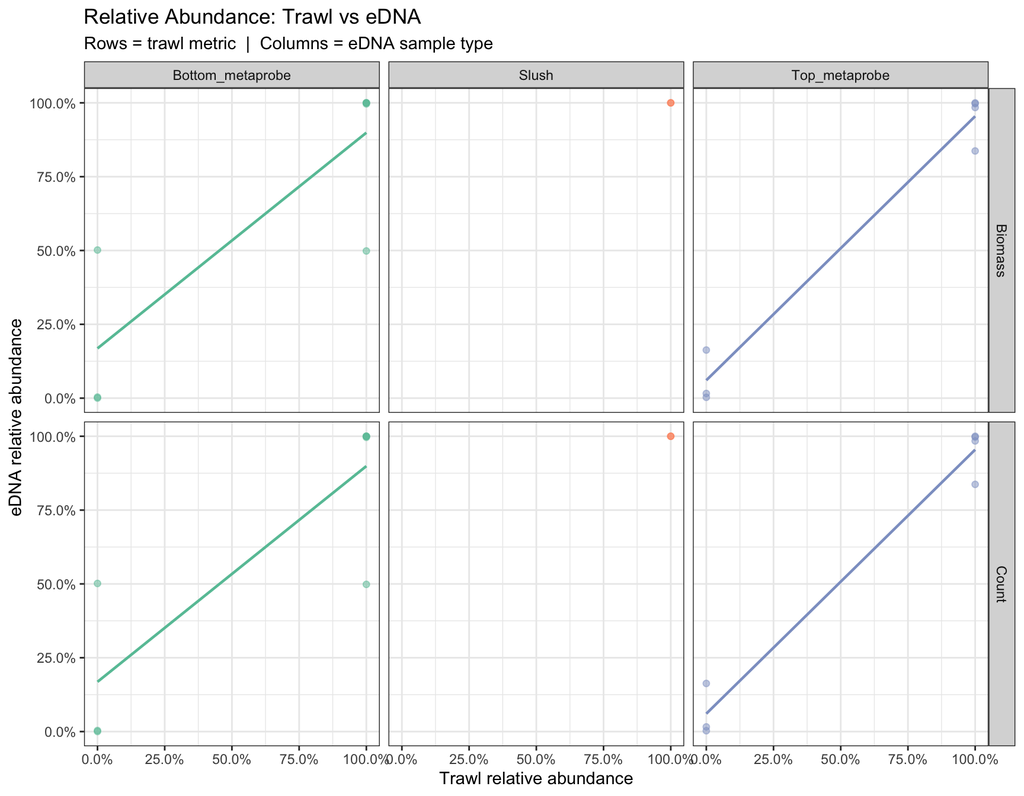

```r
# Pivot both trawl relative abundance metrics to long for faceting
rel_long <- paired %>%
  filter(!is.na(sample_type)) %>%
  select(station, species, sample_type, edna_rel,
         any_of(c("trawl_count_rel", "trawl_weight_rel"))) %>%
  pivot_longer(
    cols      = any_of(c("trawl_count_rel", "trawl_weight_rel")),
    names_to  = "trawl_metric",
    values_to = "trawl_rel"
  ) %>%
  filter(!is.na(trawl_rel), (trawl_rel > 0 | edna_rel > 0)) %>%
  mutate(trawl_metric = recode(trawl_metric,
                               "trawl_count_rel"  = "Count",
                               "trawl_weight_rel" = "Biomass"))

ggplot(rel_long, aes(x = trawl_rel, y = edna_rel, color = sample_type)) +
  geom_point(alpha = 0.5, size = 1.6) +
  geom_smooth(method = "lm", se = FALSE, linewidth = 0.8) +
  facet_grid(trawl_metric ~ sample_type) +
  scale_x_continuous(labels = scales::percent_format(accuracy = 0.1)) +
  scale_y_continuous(labels = scales::percent_format(accuracy = 0.1)) +
  scale_color_brewer(palette = "Set2", guide = "none") +
  labs(
    title = "Relative Abundance: Trawl vs eDNA",
    subtitle = "Rows = trawl metric  |  Columns = eDNA sample type",
    x = "Trawl relative abundance", y = "eDNA relative abundance"
  ) +
  theme_bw(base_size = 11)
```

## 5b. Log-transformed Pearson r — Count vs Biomass

```r
log_cor <- bind_rows(
  if (has_count) {
    paired %>%
      filter(!is.na(sample_type)) %>%
      group_by(sample_type) %>%
      filter(
        sum(!is.na(trawl_count) & !is.na(edna_reads)) >= 3,
        var(log1p(trawl_count), na.rm = TRUE) > 0,
        var(log1p(edna_reads),  na.rm = TRUE) > 0
      ) %>%
      summarise(
        trawl_metric = "Count",
        pearson_r = tryCatch(
          cor(log1p(trawl_count), log1p(edna_reads), use = "complete.obs"),
          error = function(e) NA_real_
        ),
        p_value = tryCatch(
          cor.test(log1p(trawl_count), log1p(edna_reads))$p.value,
          error = function(e) NA_real_
        ),
        .groups = "drop"
      ) %>% filter(!is.na(pearson_r))
  },
  if (has_weight) {
    paired %>%
      filter(!is.na(sample_type)) %>%
      group_by(sample_type) %>%
      filter(
        sum(!is.na(trawl_weight) & !is.na(edna_reads)) >= 3,
        var(log1p(trawl_weight), na.rm = TRUE) > 0,
        var(log1p(edna_reads),   na.rm = TRUE) > 0
      ) %>%
      summarise(
        trawl_metric = "Biomass",
        pearson_r = tryCatch(
          cor(log1p(trawl_weight), log1p(edna_reads), use = "complete.obs"),
          error = function(e) NA_real_
        ),
        p_value = tryCatch(
          cor.test(log1p(trawl_weight), log1p(edna_reads))$p.value,
          error = function(e) NA_real_
        ),
        .groups = "drop"
      ) %>% filter(!is.na(pearson_r))
  }
) %>%
  mutate(sig = case_when(
    p_value < 0.001 ~ "***",
    p_value < 0.01  ~ "**",
    p_value < 0.05  ~ "*",
    TRUE ~ "ns"
  ))

log_cor %>%
  mutate(pearson_r = round(pearson_r, 3), p_value = signif(p_value, 3)) %>%
  arrange(sample_type, trawl_metric) %>%
  kable(caption = "Pearson r on log1p(abundance): Count vs Biomass, by sample type",
        col.names = c("Sample Type", "Trawl metric", "Pearson r", "p-value", "Sig.")) %>%
  kable_styling(bootstrap_options = c("striped", "hover"), full_width = FALSE) %>%
  collapse_rows(columns = 1, valign = "top")
```

Pearson r on log1p(abundance): Count vs Biomass, by sample type

| Sample Type | Trawl metric | Pearson r | p-value | Sig. |
| --- | --- | --- | --- | --- |
| Bottom_metaprobe | Biomass | 0.319 | 0.368 | ns |
|  | Count | 0.402 | 0.250 | ns |
| Top_metaprobe | Biomass | 0.394 | 0.294 | ns |
|  | Count | 0.464 | 0.208 | ns |

# 6. Differences Among eDNA Sample Types

## 6a. Kruskal-Wallis + Dunn post-hoc test on ρ values

```r
# Test whether station-level ρ differs by sample type
kw_result <- kruskal.test(rho ~ sample_type, data = spearman_station)
kw_tidy <- tidy(kw_result)

cat("Kruskal-Wallis test: H =", round(kw_tidy$statistic, 3),
    ", df =", kw_tidy$parameter,
    ", p =", signif(kw_tidy$p.value, 3), "\n")
```

```
Kruskal-Wallis test: H = 2.2 , df = 1 , p = 0.138
```

```r
# Pairwise Wilcoxon (Dunn-like) if K-W is significant
if (kw_tidy$p.value < 0.05 && n_distinct(spearman_station$sample_type) >= 2) {
  pairwise_result <- pairwise.wilcox.test(
    spearman_station$rho,
    spearman_station$sample_type,
    p.adjust.method = "BH"
  )
  cat("\nPairwise Wilcoxon (BH-adjusted p-values):\n")
  print(pairwise_result$p.value)
} else {
  cat("No significant difference among sample types (or <2 types), skipping post-hoc.\n")
}
```

```
No significant difference among sample types (or <2 types), skipping post-hoc.
```

## 6b. Boxplot of station-level ρ by sample type

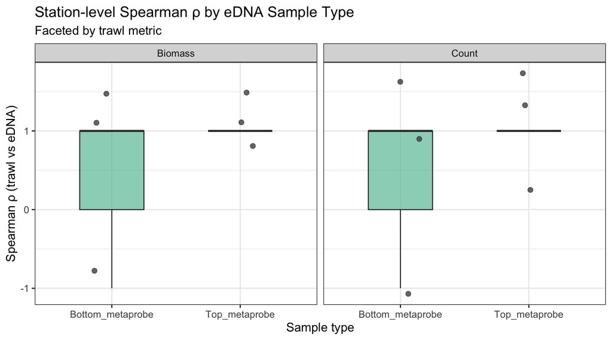

```r
ggplot(spearman_station, aes(x = sample_type, y = rho, fill = sample_type)) +
  geom_boxplot(outlier.shape = NA, alpha = 0.7, width = 0.5) +
  geom_jitter(width = 0.15, size = 2.2, alpha = 0.8, color = "grey30") +
  facet_wrap(~trawl_metric, ncol = 2) +
  scale_fill_brewer(palette = "Set2", guide = "none") +
  labs(
    title = "Station-level Spearman ρ by eDNA Sample Type",
    subtitle = "Faceted by trawl metric",
    x = "Sample type", y = "Spearman ρ (trawl vs eDNA)"
  ) +
  theme_bw(base_size = 13)
```

## 6c. NMDS ordination — do sample types cluster separately?

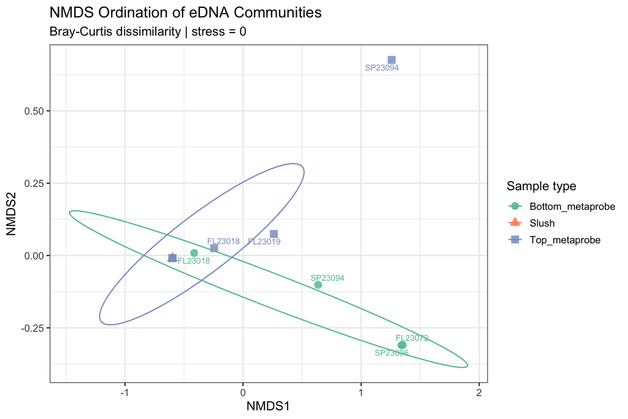

```r
# Build community matrix: station × species, summed reads, per sample type
nmds_list <- edna_agg %>%
  filter(station %in% shared_stations) %>%
  group_by(station, sample_type) %>%
  pivot_wider(names_from = species, values_from = edna_reads, values_fill = 0) %>%
  ungroup()

nmds_meta <- nmds_list %>% select(station, sample_type)
nmds_mat  <- nmds_list %>% select(-station, -sample_type) %>% as.matrix()

# Remove all-zero rows/cols
keep_rows <- rowSums(nmds_mat) > 0
keep_cols <- colSums(nmds_mat) > 0
nmds_mat  <- nmds_mat[keep_rows, keep_cols]
nmds_meta <- nmds_meta[keep_rows, ]

if (nrow(nmds_mat) >= 3) {
  set.seed(42)
  ord <- metaMDS(nmds_mat, distance = "bray", k = 2, trymax = 100, trace = FALSE)

  scores_df <- as.data.frame(scores(ord, "sites")) %>%
    bind_cols(nmds_meta)

  ggplot(scores_df, aes(x = NMDS1, y = NMDS2, color = sample_type, shape = sample_type)) +
    geom_point(size = 3.5, alpha = 0.85) +
    geom_text_repel(aes(label = station), size = 3, max.overlaps = 10) +
    stat_ellipse(aes(group = sample_type), type = "t", level = 0.75, linewidth = 0.6) +
    scale_color_brewer(palette = "Set2") +
    labs(
      title = "NMDS Ordination of eDNA Communities",
      subtitle = paste0("Bray-Curtis dissimilarity | stress = ", round(ord$stress, 3)),
      color = "Sample type", shape = "Sample type"
    ) +
    theme_bw(base_size = 13)
} else {
  cat("Insufficient observations for NMDS.\n")
}
```

## 6d. PERMANOVA — do sample types differ in community composition?

```r
if (nrow(nmds_mat) >= 3) {
  perm_result <- adonis2(
    nmds_mat ~ sample_type + station,
    data    = nmds_meta,
    method  = "bray",
    permutations = 999
  )
  print(perm_result)
} else {
  cat("Insufficient observations for PERMANOVA.\n")
}
```

```
Permutation test for adonis under reduced model
Permutation: free
Number of permutations: 999

adonis2(formula = nmds_mat ~ sample_type + station, data = nmds_meta, permutations = 999, method = "bray")
         Df SumOfSqs      R2     F Pr(>F)
Model     8   3.8150 0.82503 2.947  0.012 *
Residual  5   0.8091 0.17497
Total    13   4.6241 1.00000
---
Signif. codes:  0 '***' 0.001 '**' 0.01 '*' 0.05 '.' 0.1 ' ' 1
```

# 7. Species Detected by Either Method

This section shows mean relative abundance (trawl) and mean relative abundance (eDNA) side by side for all species detected by **either** the trawl or the eDNA survey across paired stations. This is more informative than restricting to top trawl species when the eDNA primer targets a specific taxonomic group (e.g. cephalopods) that may represent a small fraction of trawl catch.

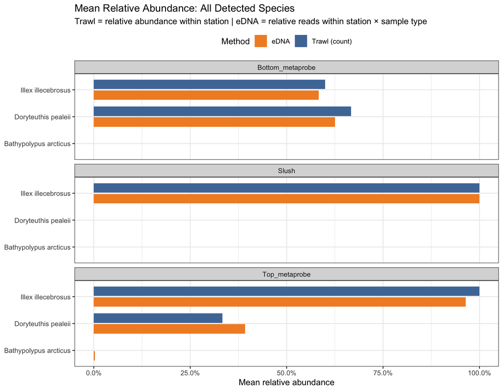

```r
# Choose the primary trawl relative abundance metric
primary_trawl_rel <- if (has_count) "trawl_count_rel" else "trawl_weight_rel"
primary_label     <- if (has_count) "Trawl (count)"   else "Trawl (biomass)"

# All species detected by trawl OR eDNA across paired stations
focal_sp <- paired %>%
  filter(!is.na(sample_type)) %>%
  filter(edna_reads > 0 | .data[[if (has_count) "trawl_count" else "trawl_weight"]] > 0) %>%
  pull(species) %>% unique() %>% sort()

top_paired <- paired %>%
  filter(species %in% focal_sp, !is.na(sample_type)) %>%
  group_by(species, sample_type) %>%
  summarise(
    mean_trawl_rel = mean(.data[[primary_trawl_rel]], na.rm = TRUE),
    mean_edna_rel  = mean(edna_rel, na.rm = TRUE),
    .groups = "drop"
  ) %>%
  pivot_longer(c(mean_trawl_rel, mean_edna_rel),
               names_to = "method", values_to = "mean_rel_abund") %>%
  mutate(method = recode(method,
                         "mean_trawl_rel" = primary_label,
                         "mean_edna_rel"  = "eDNA"))

if (nrow(top_paired) == 0 || n_distinct(top_paired$species) == 0) {
  cat("No species detected by either method in paired stations.\n")
} else {
  n_types <- n_distinct(top_paired$sample_type)

  p <- ggplot(top_paired,
              aes(x = reorder(species, mean_rel_abund),
                  y = mean_rel_abund,
                  fill = method)) +
    geom_col(position = position_dodge(0.8), width = 0.7) +
    scale_fill_manual(values = setNames(c("#4e79a7", "#f28e2b"),
                                        c(primary_label, "eDNA"))) +
    scale_y_continuous(labels = scales::percent_format(accuracy = 0.1)) +
    coord_flip() +
    labs(
      title    = "Mean Relative Abundance: All Detected Species",
      subtitle = "Trawl = relative abundance within station | eDNA = relative reads within station × sample type",
      x = NULL, y = "Mean relative abundance", fill = "Method"
    ) +
    theme_bw(base_size = 11) +
    theme(legend.position = "top")

  if (n_types > 1) {
    p <- p + facet_wrap(~sample_type, ncol = 1)
  } else {
    p <- p + labs(caption = paste("eDNA sample type:", unique(top_paired$sample_type)))
  }

  print(p)
}
```